# Part II - (Ford GoBike System Data)

## by (Manuel Tekena)

## Investigation Overview

> In this analysis, I would like to show the relationship between the subcribers and members which are the user type in regards to how much they make up the total trips in the top 5 stations as well as how much the different genders make up the the total trips also. I would also like to look at the age distribution of both the male and female users

## Dataset Overview

> I wil be using a modified dataset of my top5 stations dataframe which includes only the first 500 trips of my top5 stations

## Distribution of User Type in Top 5 Stations

> The visualization below shows the top 5 busiest stations and it shows how much of its customers and subscribers make up the total trips. From the small subset chosen to perfomr this analysis it is clear that the subscribers make up the majority of trips taken in all the five stations

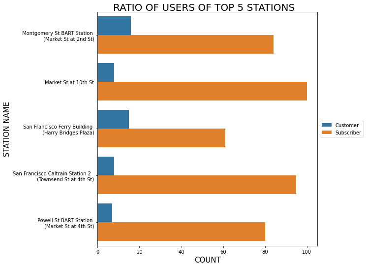

## Distribution of Gender in Top 5 Stations

> The visualization below shows the top 5 busiest stations and it reveals the gender ratio of its total trips. From the small subset of the dataframe chosen to perform this analysis it is clear that the males make up the majority of trips taken in all the five stations

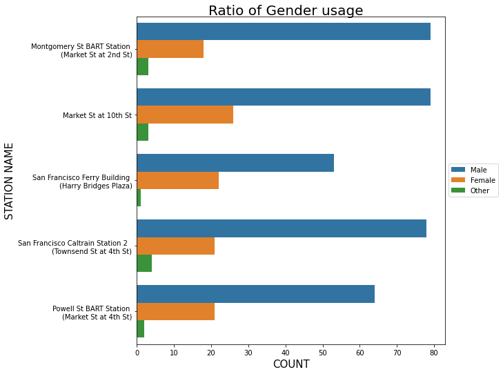

## Distribution of Gender Types

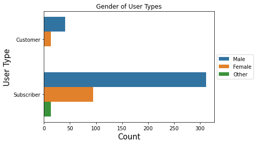

## Female Age Distribution in Top 5 Station

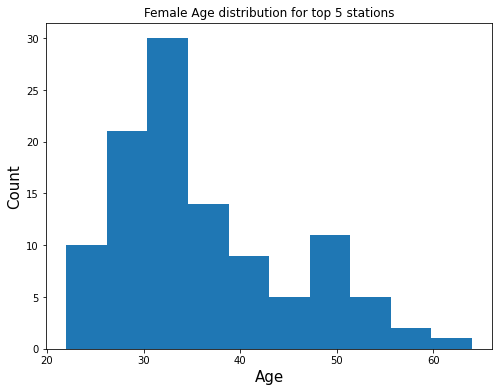

## Male Age Distribution in Top 5 Stations

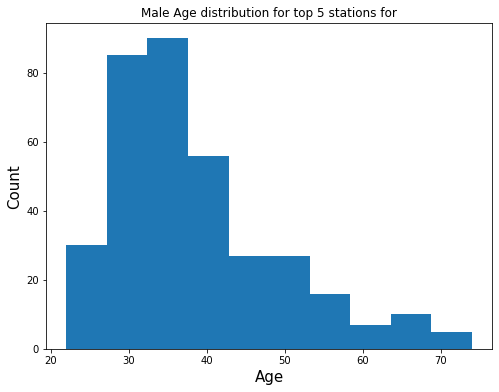